# Stroop Effect Hypotheses Test by Ronan Casey

This document presents a hypotheses test using results from a Stroop Effect experiment.  
Our independent variable is whether or not the word is congruent with the colour of print.  
Our dependent variable is the time taken to complete each test in seconds.

The null hypothesis will be that the difference in time taken to complete each test is insignificant, whether or not the word is congruent with the print colour.

The alternate hypothesis will be that when the word is incongruent with the print colour, the time taken to complete the test will be significantly longer.

H<sub>0</sub>: μC = μI  
H<sub>1</sub>: μC < μI  
$\alpha$: 0.0005

μC = mean time taken to complete test where word and print colour are congruent.  
μI = mean time taken to complete test where word and print colour are incongruent.

Seeing as the population means are unknown, and the sample groups include the same individuals, I will perform a paired t-test in an attempt to prove the alternate hypothesis. The aim is to highlight a significantly longer time taken to complete the test where word and print colour are incongruent.

```
##    Congruent      Incongruent
##  Min.   : 8.63   Min.   :15.69
##  1st Qu.:11.90   1st Qu.:18.72
##  Median :14.36   Median :21.02
##  Mean   :14.05   Mean   :22.02
##  3rd Qu.:16.20   3rd Qu.:24.05
##  Max.   :22.33   Max.   :35.26
```

The sample size is n=24. The mean time taken to complete the test when word and colour are congruent (μC) is 14.05 seconds with a standard deviation of 3.56 seconds. The mean time taken to complete the test when word and colour are incongruent (μI) is 22.02 seconds with a standard deviation of 4.80 seconds.

### Distribution Plots

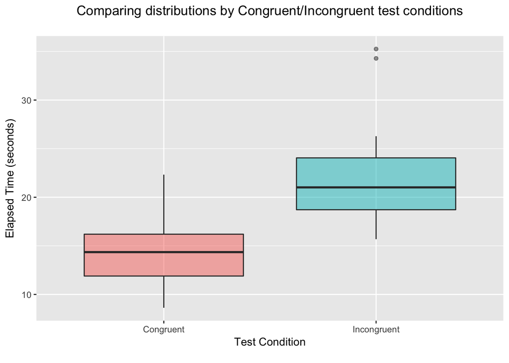

In the plot above we can see that the third quartile for Congruent conditions falls short of the first quartile for Incongruent conditions and is not much higher than the lowest recorded time for Incongruent conditions.

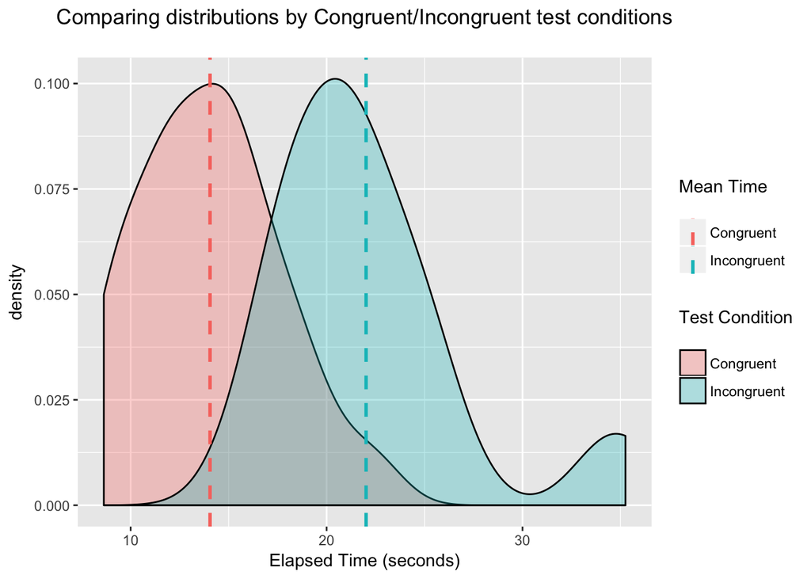

The plot above shows the distributions for each test condition with mean time elapsed repesented by a dotted line for each condition. We can clearly identify that when the word and colour didn’t match up, the reaction time for participants was significantly longer.

### Statistical Test

H<sub>1</sub>:μC < μI, paired t-test, $\alpha$=0.0005

- mean difference (μI - μC) = 7.965
- standard deviation of differences = 4.865
- standard error of mean difference = 0.993
- t-statistic = 8.021
- t-critical = 3.768
- p-value < 0.0001
- H<sub>0</sub> is rejected.

The t-critical value required to meet $\alpha$=0.0005 has a value of 3.768. The resulting t-statistic is found outside this zone at 8.021. The null hypothesis is rejected at a confidence level above 99.9%, meaning that the time taken to complete the test under incongruent conditions will almost certainly be longer when the participant is the same.

### Resulting Hypotheses

The act of reading prioitizes the meaning of the word over the aesthetic attributes of the print. The stroop experiment calls on the participant to do something which contradicts the learned response, which is reading. It could also be explained where there is a conflict of prioritization when sharing neural circuitry for independant tasks, in this case word meaning and aesthetic attributes. When the pairing is congruent, there is no conflict and both processes work in parallel. The introduction of incongruence gives rise to some confusion and the participant gets a bit flustered.

### Sources

- https://en.wikipedia.org/wiki/Stroop_effect
- https://www.psytoolkit.org/lessons/stroop.html